# Sensitivity Analysis: Temporal Validation

26 August 2026

**Associated manuscript: A flexible approach to sequential prediction under intervention**

# 1 Overview and methodology

This report summarises performance of the two-component model under temporal validation, where the index dates are defined 1, 2, 3, 4 or 5 years after the start of follow-up.

Start of follow-up is defined as the maximum of: date turned 18; 1 year up to standard follow-up in CPRD; 1st January 2005. This is what was used as the index date in the main manuscript when developing and validating the models. For $t_{fup}$ in $\{1,2,3,4,5\}$, validation cohorts were restricted to individuals who remained event free and under follow-up within $t_{fup}$ years of their start of follow-up. Time until incident cardiovascular event was then defined relative to these new index dates. We refer to these as temporal validation cohorts.

Section 2 contains a summary table of calibration (ICI, E50, E90) and discrimination (C-statistic) metrics, with 95% confidence intervals. Section 3 contains calibration plots (plus grouped Kaplan-Meier estimates vs mean predicted risk in 25 groups defined by predicted risk).

# 2 Summary Table of Performance Metrics

We find that as the index date gets further away from start of follow-up, the calibration gets worse (symptomatic of calibration drift), however not by a large amount. There is a more considerable drop in discrimination (0.863 to 0.838 for females, 0.845 to 0.814 for males). This is likely due to higher risk individuals having events in the first 5 years and being removed from the validation cohort. This will result in a healthier cohort, within which it is harder to discriminate between high and low risk individuals.

Calibration and discrimination metrics (95% CI)

| Follow-up (years) | N | ICI | E50 | E90 | C-statistic |
| --- | --- | --- | --- | --- | --- |
| Male |  |  |  |  |  |
| 1 | 850304 | 0.001 (0.001, 0.001) | 0.000 (0.000, 0.001) | 0.001 (0.001, 0.002) | 0.845 (0.845, 0.845) |
| 2 | 727831 | 0.001 (0.001, 0.002) | 0.001 (0.000, 0.001) | 0.003 (0.002, 0.004) | 0.837 (0.837, 0.837) |
| 3 | 628389 | 0.002 (0.002, 0.003) | 0.001 (0.001, 0.002) | 0.005 (0.003, 0.006) | 0.829 (0.829, 0.829) |
| 4 | 547071 | 0.003 (0.002, 0.003) | 0.002 (0.001, 0.002) | 0.007 (0.004, 0.008) | 0.821 (0.821, 0.821) |
| 5 | 481009 | 0.004 (0.003, 0.004) | 0.002 (0.002, 0.003) | 0.009 (0.007, 0.010) | 0.814 (0.814, 0.814) |
| Female |  |  |  |  |  |
| 1 | 826655 | 0.001 (0.001, 0.001) | 0.000 (0.000, 0.001) | 0.002 (0.001, 0.003) | 0.863 (0.863, 0.863) |
| 2 | 692698 | 0.002 (0.001, 0.002) | 0.001 (0.000, 0.001) | 0.004 (0.002, 0.005) | 0.855 (0.855, 0.855) |
| 3 | 590933 | 0.002 (0.002, 0.003) | 0.001 (0.001, 0.001) | 0.006 (0.004, 0.007) | 0.849 (0.849, 0.849) |
| 4 | 515915 | 0.003 (0.002, 0.003) | 0.001 (0.001, 0.002) | 0.008 (0.006, 0.009) | 0.843 (0.843, 0.843) |
| 5 | 455388 | 0.004 (0.003, 0.004) | 0.001 (0.001, 0.002) | 0.011 (0.008, 0.012) | 0.838 (0.838, 0.838) |

# 3 Calibration Plots

The plots below show the smoothed calibration curve (red line) together with grouped Kaplan-Meier estimates (points, with 95% confidence intervals) across 25 risk groups, for each gender and follow-up time.

We observe a calibration drift, and find that as the index date gets further away from start of follow-up, the model begins to over predict. This aligns with previous research which highlights a downwards secular trend in the incidence of cardiovascular disease observed in UK primary care (Pate, Staa, and Emsley 2020). The magnitude of the misscalibration is not large

## 3.1 Female

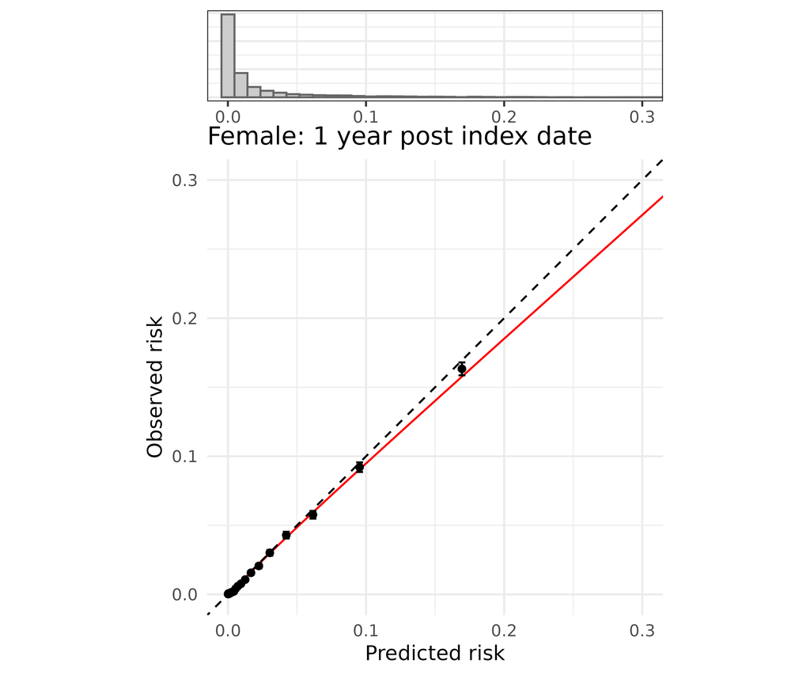

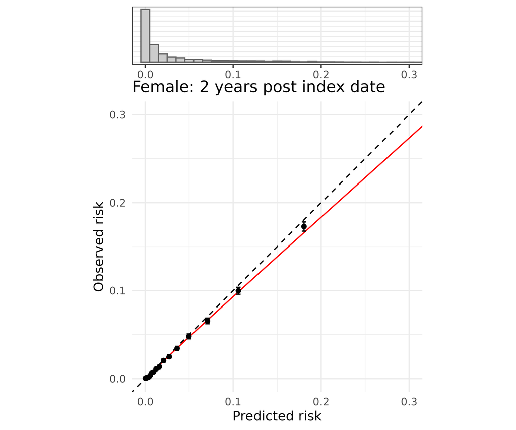

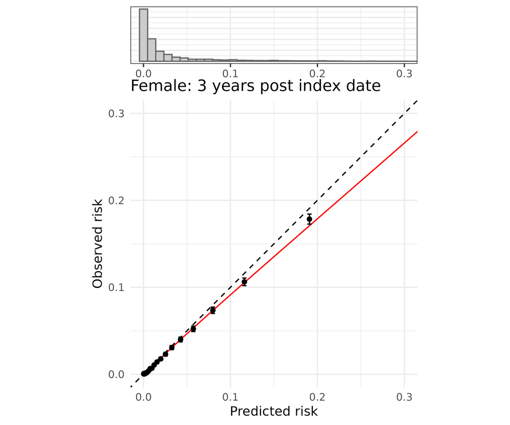

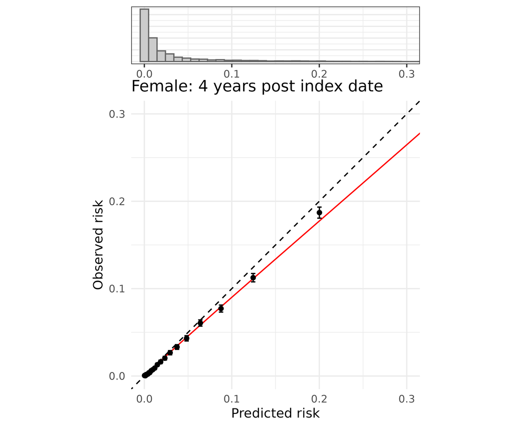

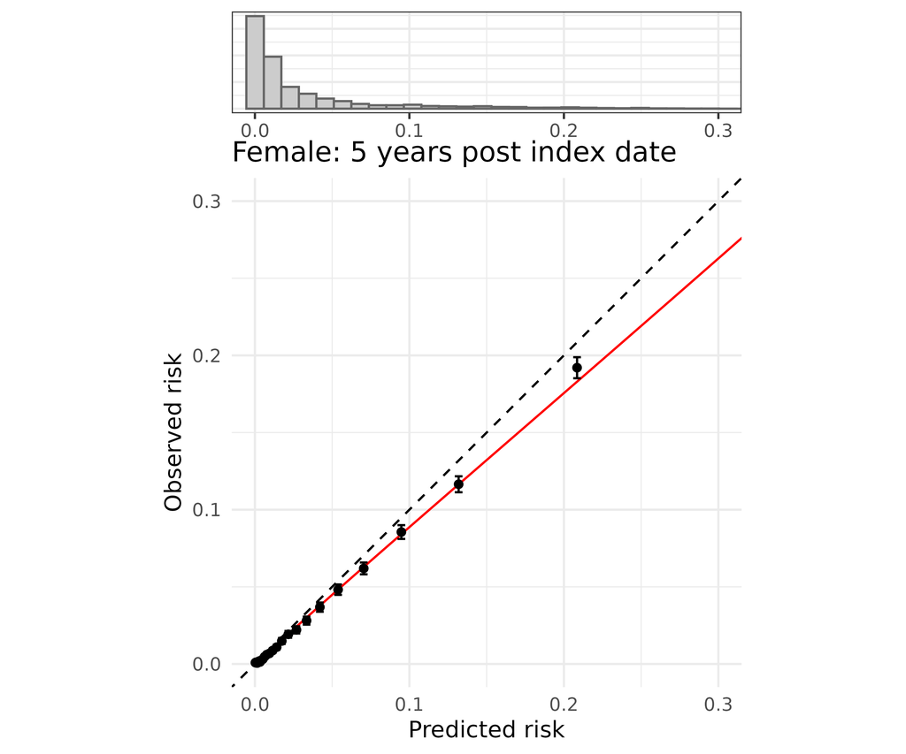

## 3.2 Male

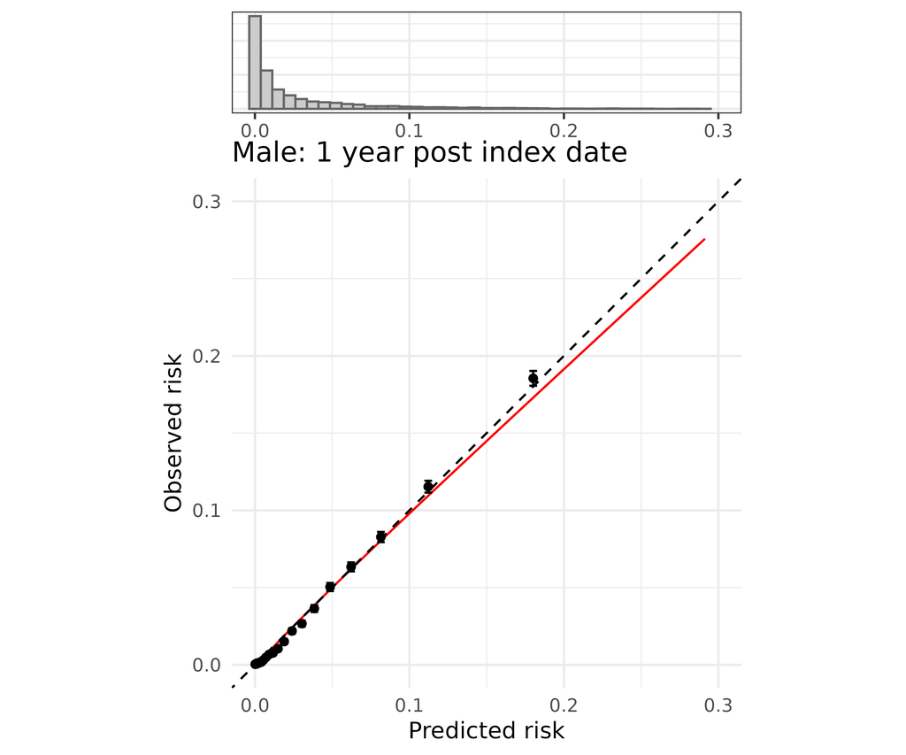

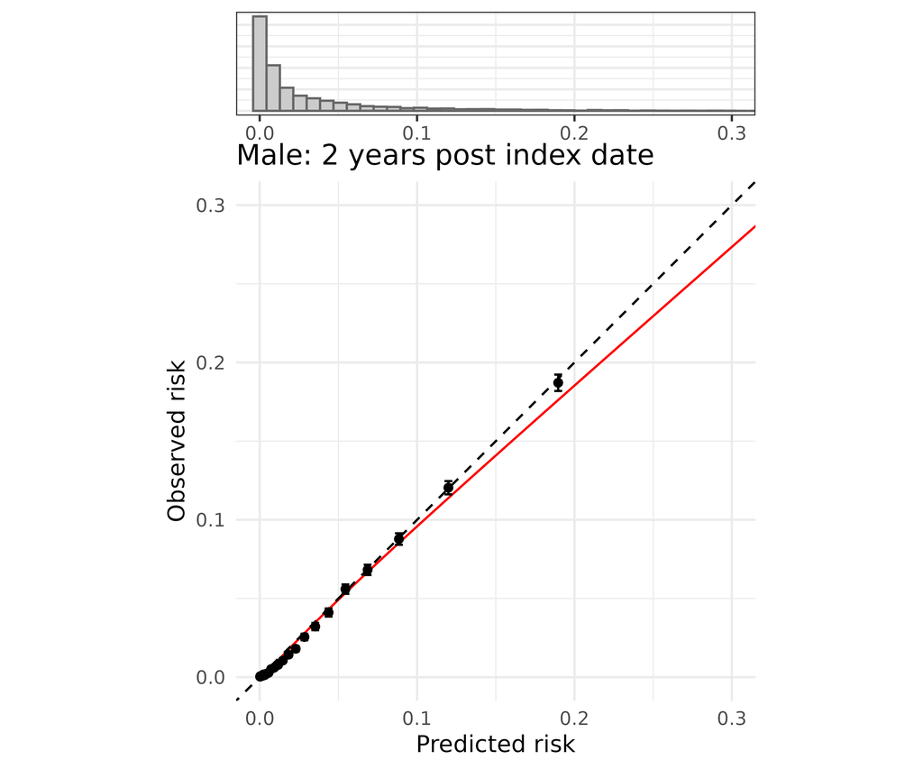

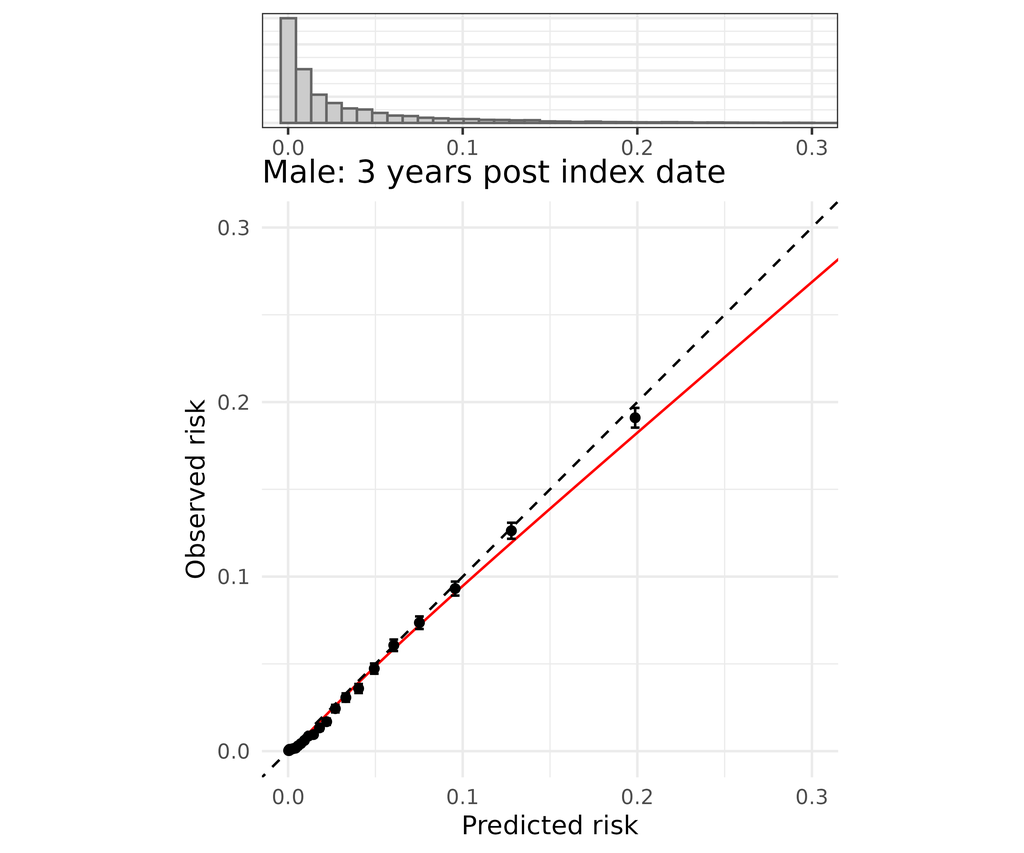

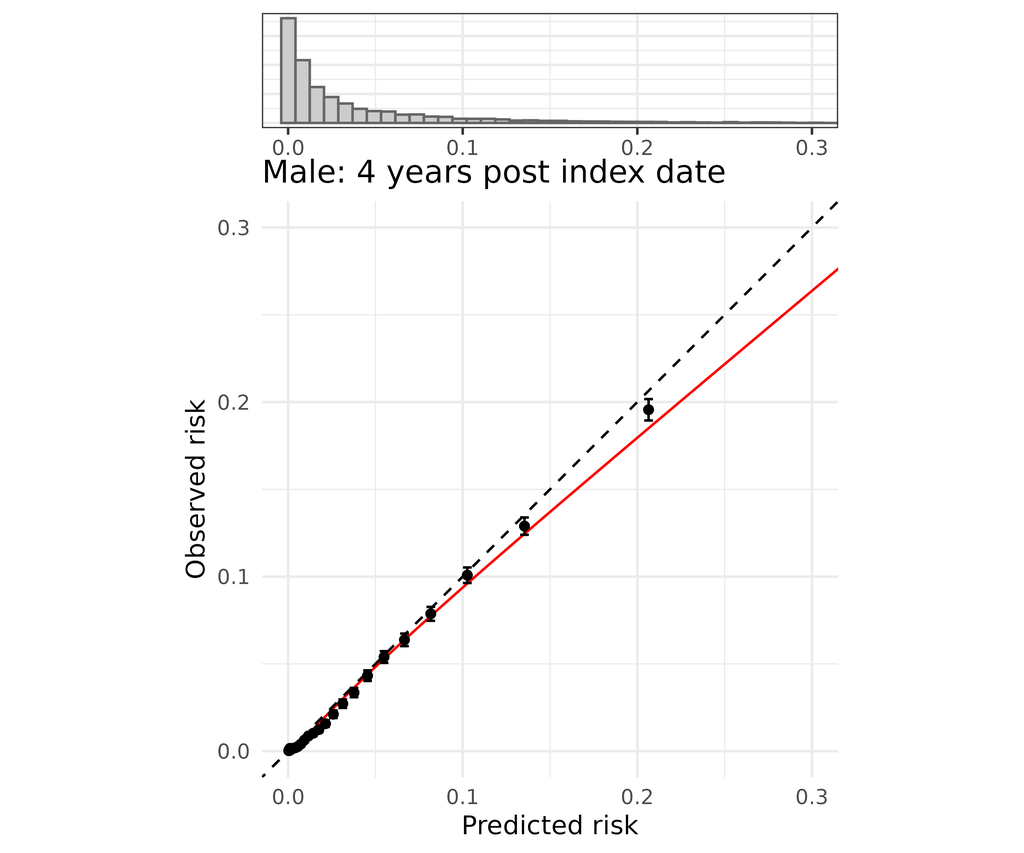

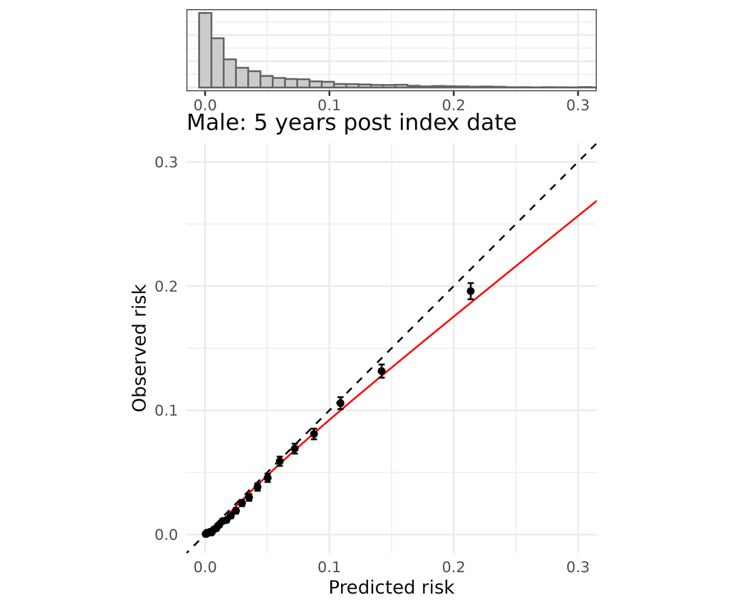

Pate, Alexander, Tjeerd van Staa, and Richard Emsley. 2020. “An Assessment of the Potential Miscalibration of Cardiovascular Disease Risk Predictions Caused by a Secular Trend in Cardiovascular Disease in England.” Journal Article. *BMC Medical Research Methodology* 20 (1): 1–12. doi:10.1186/s12874-020-01173-x.